# Data Centers

POLISCI 158 · Session 12 · Monday, November 2, 2026 · Simone Paci

## Data centers today: three questions

I.

What does AI need from a place?

- Explain why data centers concentrate costs locally while their benefits are diffuse, and why that produces siting conflict.

II.

When and why do data centers generate political conflict?

- Read the paper’s event-study figures and explain why announcements drew contention only after ChatGPT’s release.

III.

What does backlash do?

- Pose the next question and say why it is hard to identify.

Bonus: an AI-native paper

## A data center wants to build in a town like yours. What happens?

Predict: does the town end up saying yes or no?

Show of hands

# What does AI need from a place?

Land, power and water, somewhere.

## How much electricity do data centers use, compared with US manufacturing?

2023: about one-fifth as much as US manufacturing

2028 (projected): approaches three-fifths

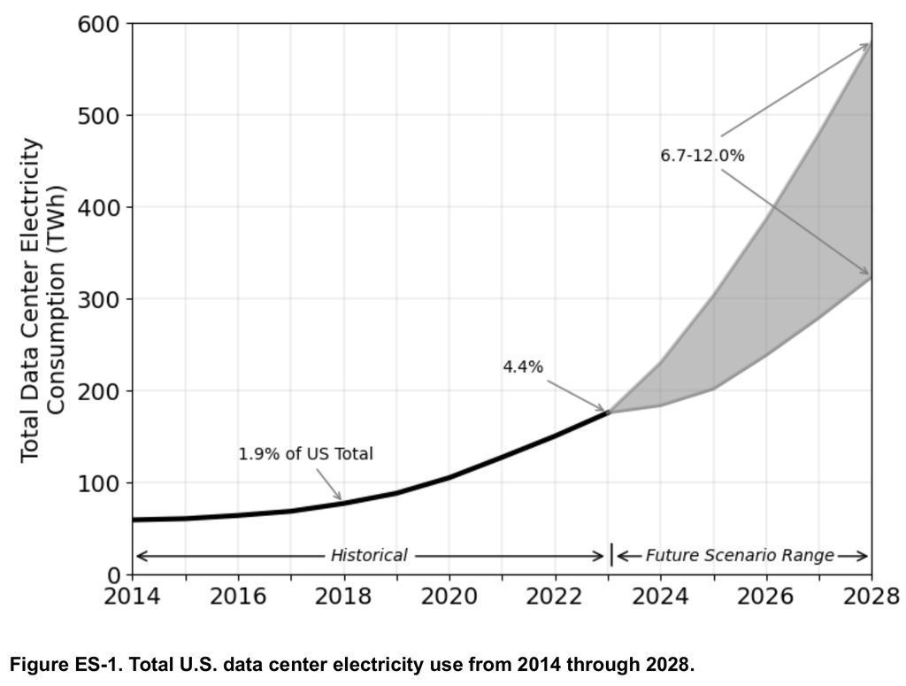

Shehabi et al. (2024), LBNL, 2024 United States Data Center Energy Usage Report, Fig. ES-1 · https://eta.lbl.gov/publications/2024-lbnl-data-center-energy-usage-report · benchmark: EIA, 2022 Manufacturing Energy Consumption Survey, Table 5.3

## Where does AI’s computing power go: training or inference?

80–90%

of computing power for AI is used for inference

- MIT Technology Review estimate

O’Donnell and Crownhart, MIT Technology Review, May 20, 2025 · https://www.technologyreview.com/2025/05/20/1116327/ai-energy-usage-climate-footprint-big-tech/

## How big is the boom?

AI-related investment, first three quarters of 2025

0.97 percentage points of real GDP growth · **39%** of all growth

2000, dot-com peak: 28%

Excluding data centers: 36% vs 28%

|  | 2000 | First 9 months of 2025 |
| --- | --- | --- |
| Information processing equipment | 0.58 | 0.42 |
| Software | 0.11 | 0.35 |
| R&D | 0.12 | 0.13 |
| Data centers | — | 0.07 |

Contribution to real GDP growth, percentage points. Rebuilt from the St. Louis Fed table.

Rubinton and Patro, Federal Reserve Bank of St. Louis, January 12, 2026 · https://www.stlouisfed.org/on-the-economy/2026/jan/tracking-ai-contribution-gdp-growth

## Why do people hate this new economic boom?

Environment = public good · pollution = externality · environmental politics = collective action problem

[figure not shown]

Visible local costs → mobilization: Sexton (2020), *Journal of Conflict Resolution* · NIMBY and YIMBY land-use politics: Brouwer and Trounstine (2024), *Annual Review of Political Science*

## Is local backlash new?

Ontario, 2011: wind turbines

- Governing party lost about 4 points (proposed turbine) to 10 points (operating turbine) in nearby precincts

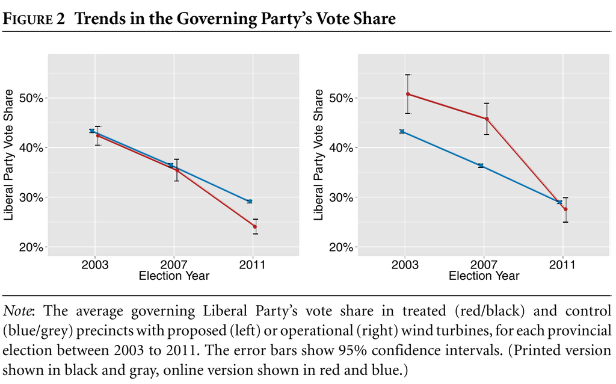

Stokes (2016), *AJPS*, Fig. 2 · https://doi.org/10.1111/ajps.12220

## Would Americans accept a data center in their own area?

[figure not shown]

Gallup, telephone poll of 1,000 US adults, March 2–18, 2026 · https://news.gallup.com/poll/709772/americans-oppose-data-centers-area.aspx

# When and why do data centers generate political conflict?

Disclosure: I co-authored the paper in this part, Paci and Russell (2026).

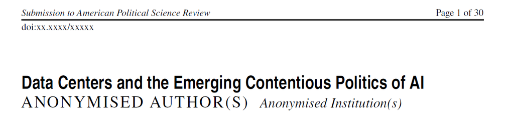

Title page, registered report submitted to the American Political Science Review, July 2026

## Where did data center announcements, protests and bills surge after 2022?

Announcements: 65 in Q4 2022 → 644 in Q1 2026

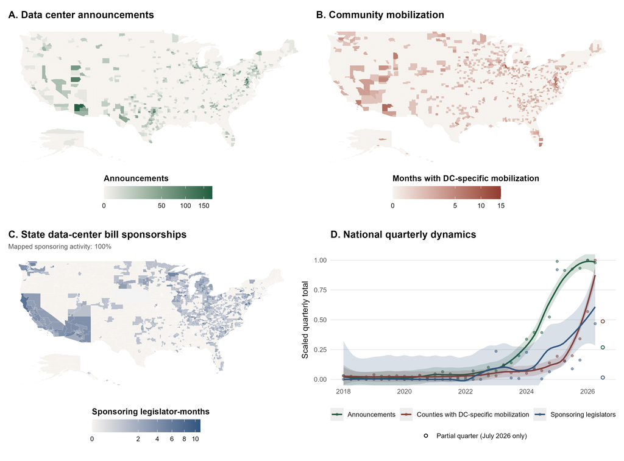

Paci and Russell (2026), Fig. 1 · https://papers.ssrn.com/sol3/papers.cfm?abstract_id=7666018

## What would explain the backlash?

**H1 · Resource competition**

Stronger where resources are already strained

**H2 · Environmental concern**

Stronger where pro-environment attitudes and mobilization are higher

**H3 · AI anxiety**

Stronger where AI-related anxiety is higher

Timing test: after ChatGPT (November 2022), an announcement means something new

Paci and Russell (2026)

## What would 1,000 Americans do about a hypothetical data center in their community?

Verasight survey, 1,000 US adults, fielded May 13–18, 2026

Four possible actions:

sign a petition

contact an official

speak at a public meeting

attend a protest

Models use 844 complete cases

## Utility prices, environment, AI: which concerns predict stated opposition?

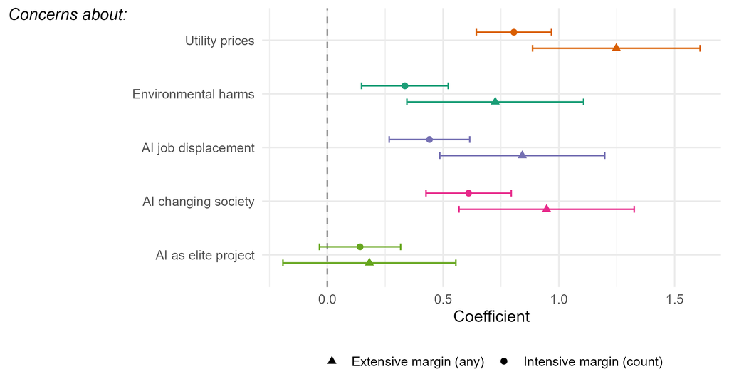

Paci and Russell (2026), Fig. 3 · https://papers.ssrn.com/sol3/papers.cfm?abstract_id=7666018

## How do we know an announcement caused anything?

1. A county’s first announcement starts its clock
2. Compare it with counties not (yet) announced, over the same quarters
3. Split by timing: first announced through November 2022 vs. from December 2022

[figure not shown]

## Where are data centers announced after 2022?

After 2022: larger labor markets and existing generation capacity

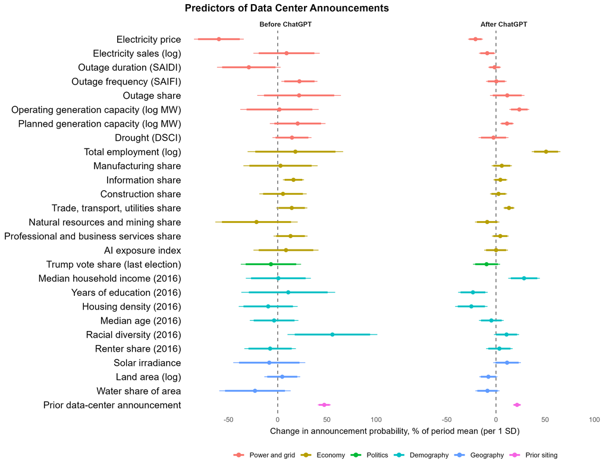

Paci and Russell (2026), Fig. 2 · https://papers.ssrn.com/sol3/papers.cfm?abstract_id=7666018

## Before and after ChatGPT: what happens after an announcement?

Sketch the line, one panel each:

- First announced through November 2022
- First announced from December 2022
1. Alone · 1 min: sketch
2. Pairs · 2 min: compare, agree on one picture

Written answers welcome

## Did announcements spark local mobilization after ChatGPT?

Through November 2022: no detectable increase

From December 2022: +6.4 percentage points in the quarterly probability of recorded contention

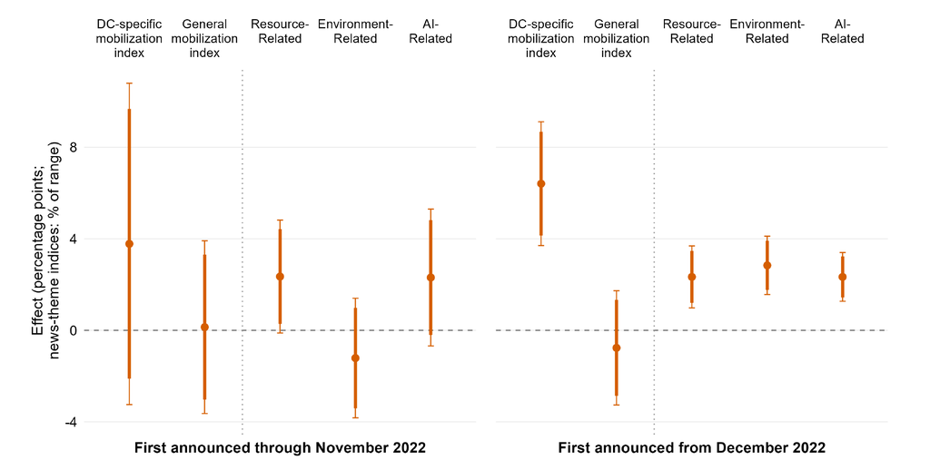

Paci and Russell (2026), Fig. 4 · https://papers.ssrn.com/sol3/papers.cfm?abstract_id=7666018

## Did state legislators switch from accommodating to restricting data centers?

Through 2022: more accommodating bills

From 2023: more restrictive bills, more than threefold the base rate

- 0.054 vs 0.015 bills per legislator-quarter

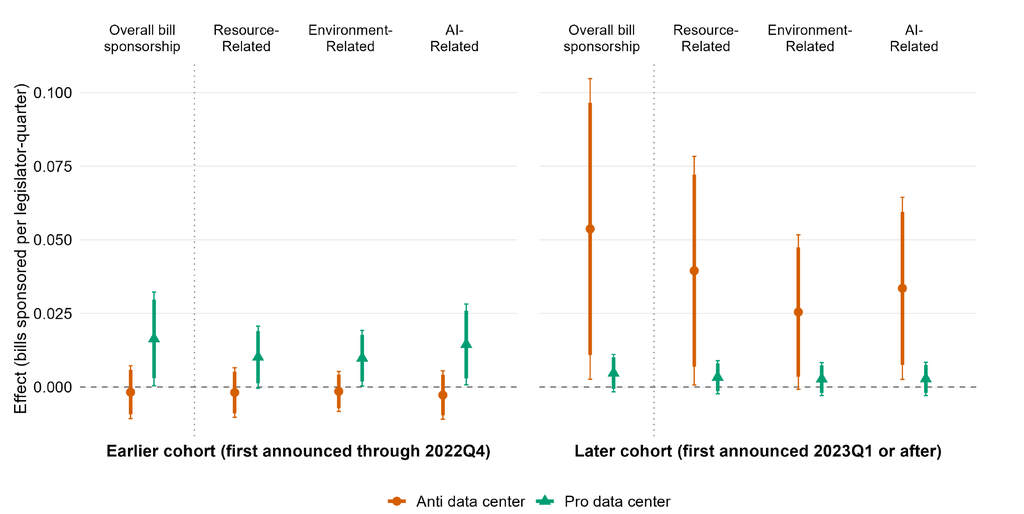

Paci and Russell (2026), Fig. 5 · https://papers.ssrn.com/sol3/papers.cfm?abstract_id=7666018

## Does strained power and water, green politics or AI exposure change the response?

No: mobilization and bill sponsorship do not vary with local conditions

Reading: a national shock; opponents fold power, water, environmental and AI grievances into one conflict

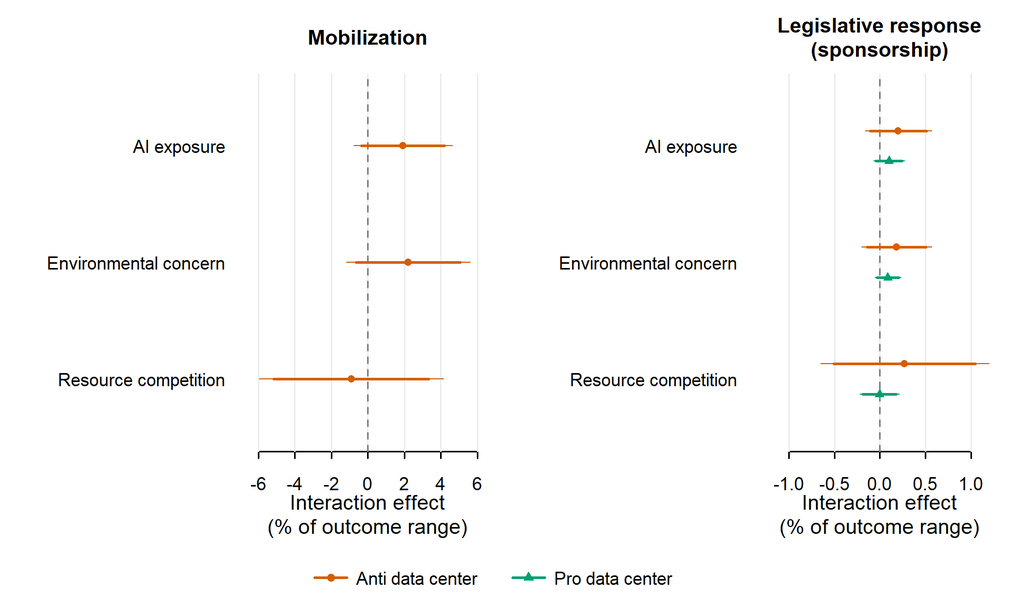

Paci and Russell (2026), Fig. 6 · https://papers.ssrn.com/sol3/papers.cfm?abstract_id=7666018 · On frame alignment in movements: Snow, Rochford, Worden and Benford (1986), *American Sociological Review*

## Do ICE detention centers and new power generation draw the data center response?

ICE detention openings: more immigration-motivated mobilization (about 4.6% of its range)

Planned power generation: more pro- and anti-utility bills (about +0.01 each per legislator-quarter)

Neither reproduces the data center response

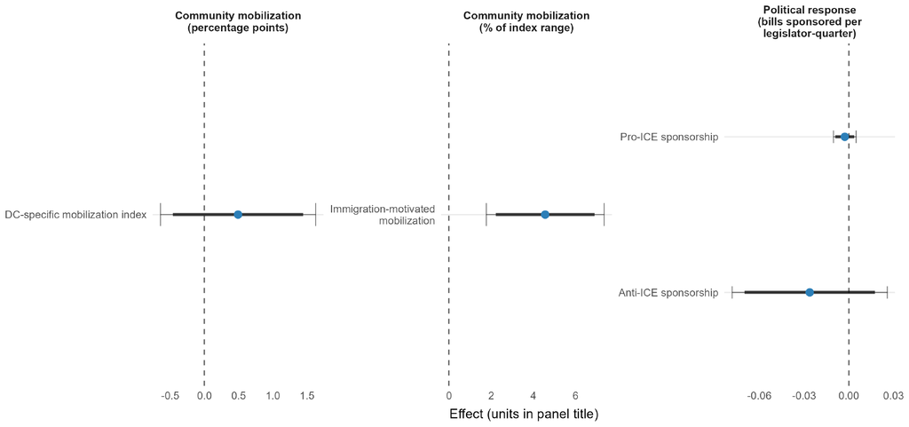

Paci and Russell (2026), Fig. D.3 · https://papers.ssrn.com/sol3/papers.cfm?abstract_id=7666018

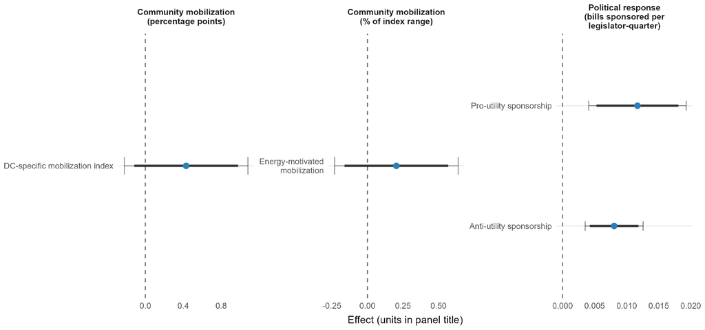

Paci and Russell (2026), Fig. D.4 · https://papers.ssrn.com/sol3/papers.cfm?abstract_id=7666018

## Data centers are contested as the AI boom’s local address

Less ordinary infrastructure than a physical embodiment of the AI boom

Partisan alignments are not settled:

- mobilization crosses party lines
- the legislative shift is weaker where Republicans hold more seats

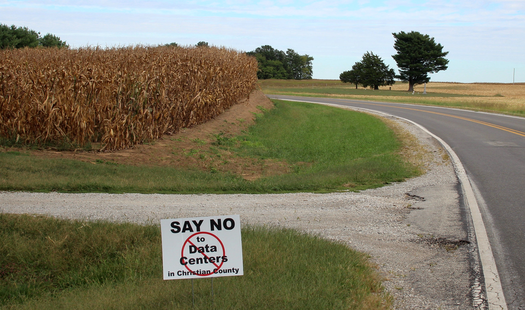

“Say No to Data Centers in Christian County” sign, Mount Auburn Township, Christian County, Illinois, September 26, 2026 · User:Visviva, Wikimedia Commons (public domain) · https://commons.wikimedia.org/wiki/File:Say_No_To_Data_Centers_in_Christian_County_sign_2026-09-26_cropped.jpg

# What does backlash do?

Work in progress

## Ballot box or buildout: how could backlash matter?

Votes: voters punish officials tied to unwanted projects

Projects: protest changes what gets built, and where

## Nuclear plants, dams, wind farms: what did earlier siting fights show?

Planners seek out acquiescent, unorganized communities for nuclear plants, dams and airports: Aldrich, *Site Fights* (2008), close to 500 Japanese municipalities

Ontario wind turbines and incumbent vote losses: Stokes 2016

Anti-nuclear movements in four democracies: Kitschelt 1986

## Will data center announcements move candidates and voters in the 2026 midterms?

Paper 2, with Emily Russell

1. Do candidates in counties with announcements mention data centers?
2. Do incumbents with data center votes draw challengers or lose?
3. Does announcement timing, relative to filing deadlines, shape who runs?

Outcomes: county vote and turnout

## The midterm paper: three comparisons, pre-registered before polls close

Announcement

Counties with and without announcements, midterms 2018, 2022, 2026

Incumbent accountability

Local ballot measures, by county and by measure

## What does backlash do to the buildout, and how much?

Paper 3, with Emily Russell

Outcomes: cancellation, delay, relocation, costs, concessions

## Why is it hard to tell whether protest cancels data centers?

In progress: none of these choices is settled.

Selection: projects that draw protest differ from those that don’t

Baselines: other unwanted infrastructure · other infrastructure · data centers before November 2022

Relocation: projects may move to places with less organizing capacity

## Midterms or cancellations: what would you want to learn?

Prompt: pick the midterm paper or the cancellations paper.

1. Think alone.
2. With a neighbour: one question, one data source, one reason the answer might mislead.
3. Share: we collect 3–4 questions from the room.

Written cards welcome; sharing is voluntary.

## Local costs, ChatGPT timing, backlash: what did we learn?

1. Data centers put costs on a town and send the benefits elsewhere: a setting for siting conflict.
2. Announcements drew contention only after ChatGPT’s release, and not more where local conditions predicted it.
3. What backlash does, to votes and to the buildout, is open and hard to identify.

Back to your town: yes or no?

## See you next class

Next: Wednesday, November 4, Computer Vision and Multimodality (Yiqing Xu)

## Our first AI-native paper: from idea to submission in a year

December 2025: first idea

March 2026: work begins

July 5, 2026: registered report submitted to the APSR (reject and resubmit as a full paper)

October 2026: full paper submitted

About 4 months of active work; a comparable traditional paper: about 2–3 years

## What did we delegate to agents, and what did we keep?

Agents

Delegated: execution

Researchers

Kept: every substantive decision: framing, empirical design, interpretation, final phrasing

Recorded: what we prompted, which model answered, what the agent did, what we changed

## Working with AI Agents and *With Great Powers*: where to read more

Working with AI Agents: https://simonepaciphd.github.io/ai-os-public/

*With Great Powers*: https://simonepaciphd.github.io/with-great-powers/

## When did Americans start hearing about data centers?

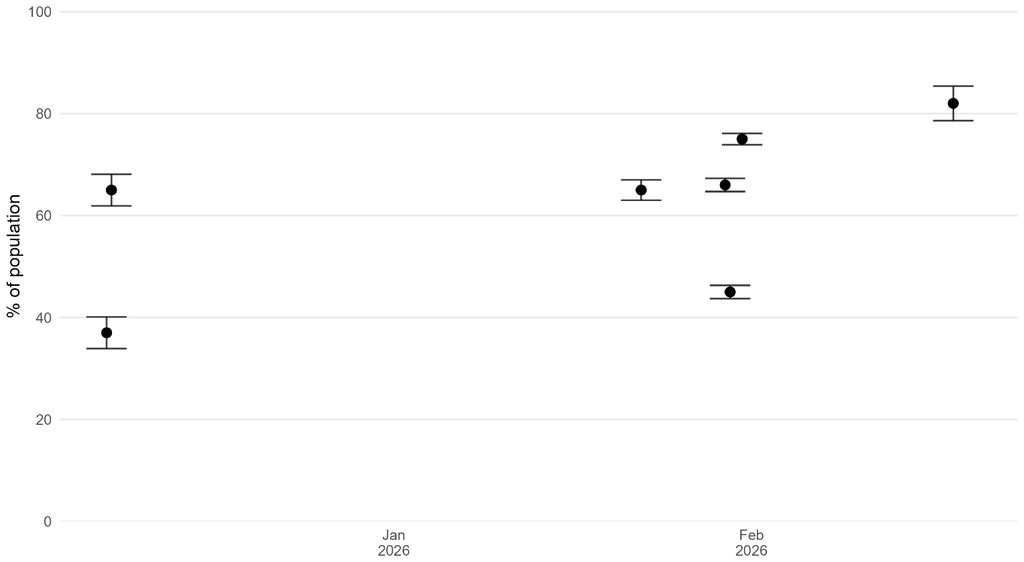

Paci and Russell (2026), Fig. F.4 · https://papers.ssrn.com/sol3/papers.cfm?abstract_id=7666018

## Equipment, software, R&D, data centers: which AI investments drove 2025 growth?

Investments in Information Processing Equipment: Contribution to GDP Growth

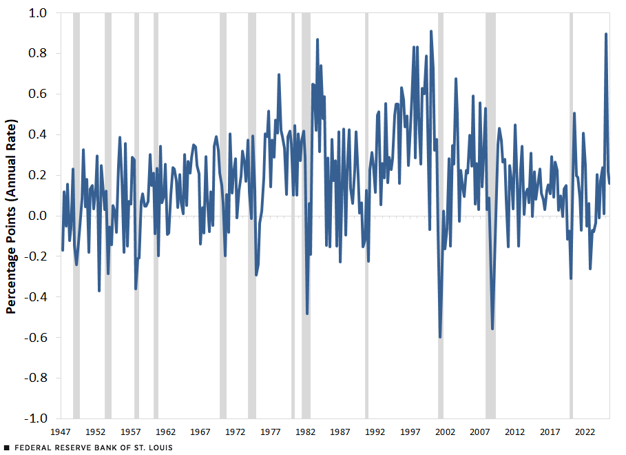

Investments in Software: Contribution to GDP Growth

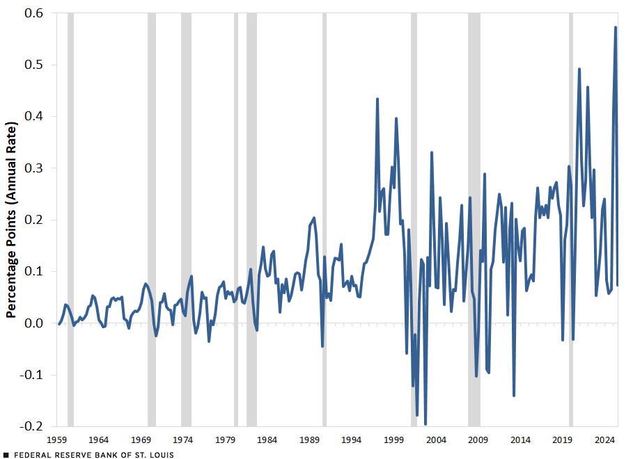

Investments in R&D: Contribution to GDP Growth

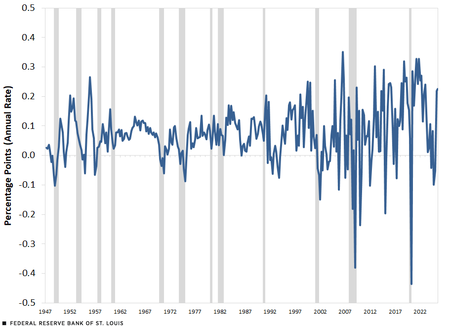

Investments in Data Centers: Contribution to GDP Growth

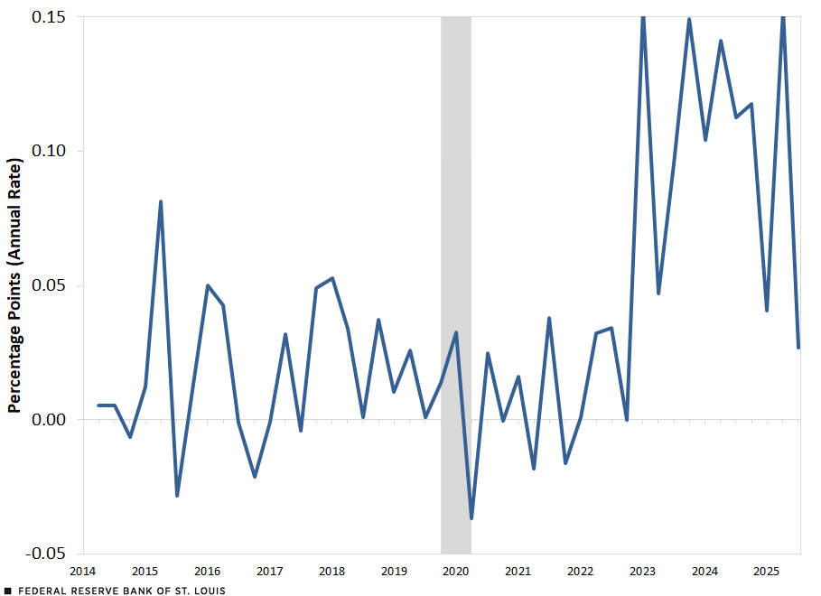

Rubinton and Patro, Federal Reserve Bank of St. Louis, January 12, 2026, Figs 1–4; data through Q3 2025 · https://www.stlouisfed.org/on-the-economy/2026/jan/tracking-ai-contribution-gdp-growth

## Who did Gallup ask in March 2026, and what did it ask?

Telephone, March 2–18, 2026: 1,000 US adults, all 50 states and DC; margin of error ±4 points

“Overall, would you strongly favor, somewhat favor, somewhat oppose, or strongly oppose the construction of a data center in your area to support artificial intelligence, or AI, technology in the U.S.?”

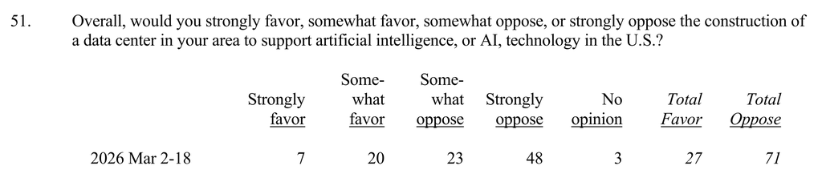

Gallup, topline, March 2–18, 2026 · https://news.gallup.com/file/poll/709808/260513_AIDataCenters.pdf

## How much does opposition to data centers depend on how pollsters ask?

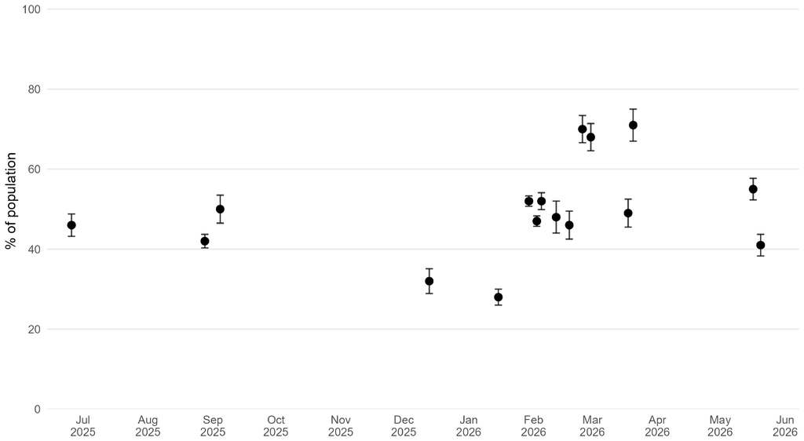

Paci and Russell (2026), Fig. F.5 · https://papers.ssrn.com/sol3/papers.cfm?abstract_id=7666018

## Who lives next to xAI’s Colossus in South Memphis?

xAI’s Colossus data center in South Memphis was sited next to Boxtown

NAACP federal Clean Air Act suit over unpermitted gas turbines powering xAI’s data centers

## Do legislators’ roll-call votes on data centers vary with AI exposure or environmental concern?

Overall, announcements do not change how legislators vote

Cohorts pooled: fewer pro-data-center votes where AI exposure or environmental concern is high

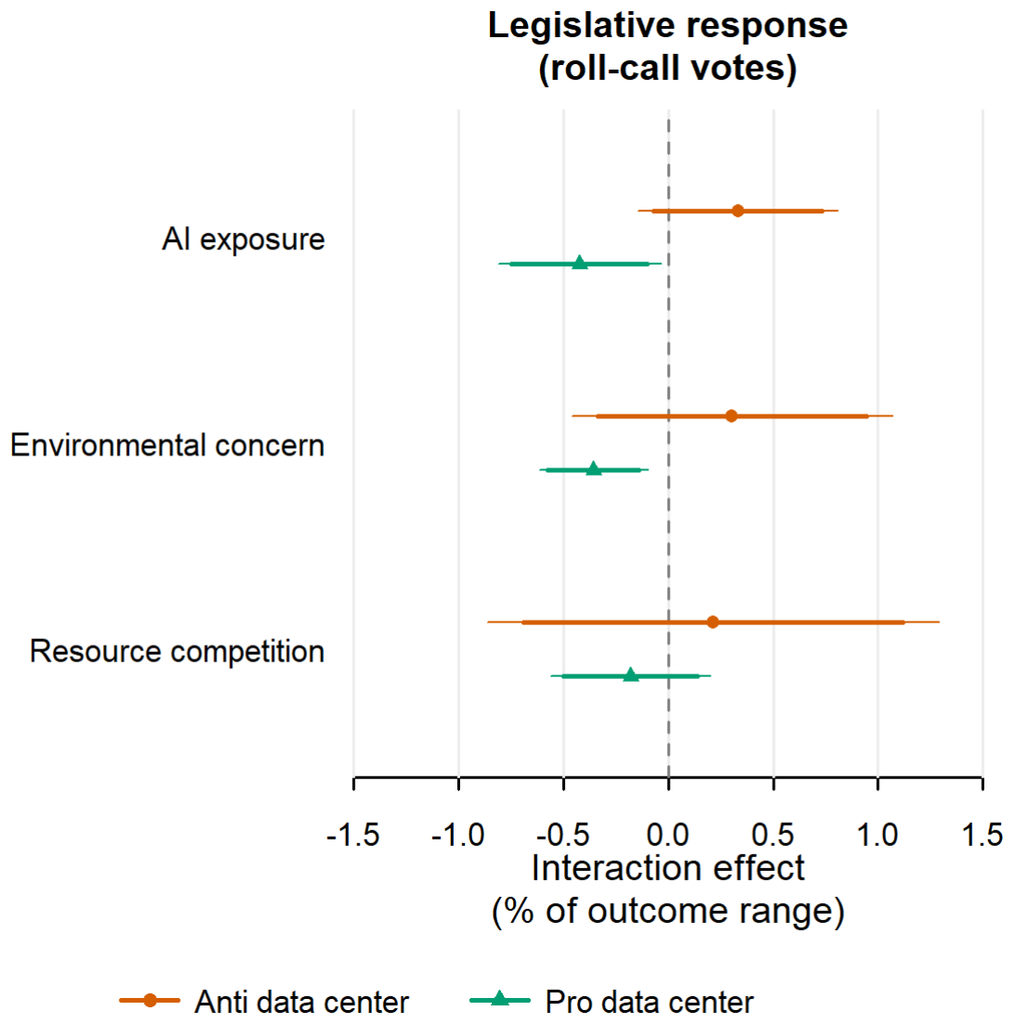

Paci and Russell (2026), Fig. E.3 · https://papers.ssrn.com/sol3/papers.cfm?abstract_id=7666018

## Do projects linked to leading AI firms draw a stronger response?

No: the two groups respond in much the same way

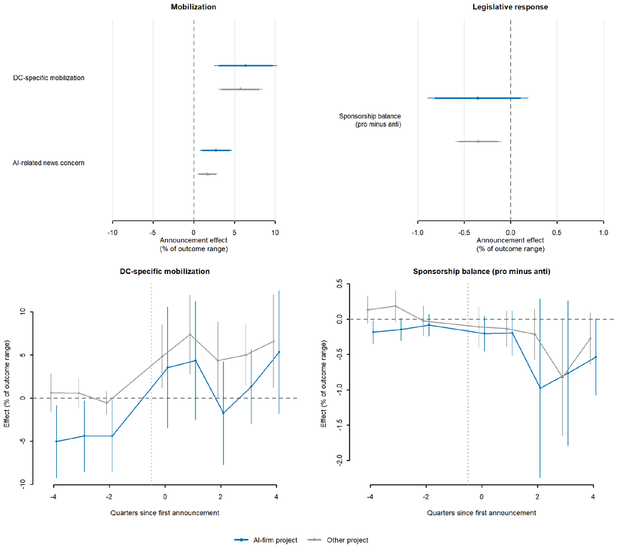

Paci and Russell (2026), Fig. E.8 · https://papers.ssrn.com/sol3/papers.cfm?abstract_id=7666018